[figure not shown]

MBA EM JORNALISMO DE DADOS  
Web scraping com Python  
Rodolfo Viana

# AULA 1 — INTRODUÇÃO

Nesta aula veremos:

1. Exemplo de raspagem no contexto de jornalismo
2. Como funciona um site
1. HTML
2. CSS
3. Ferramentas

# Exemplo de raspagem no contexto de jornalismo

Começamos aqui o módulo de *web scraping* (ou, em português, raspagem de dados). Trata-se de uma **técnica de extração de informações dispostas em websites ou aplicações**. Isso pode ser feito manualmente, por meio de sistemas específicos (como [webscraper.io](https://webscraper.io/)), ou a partir da criação de um script (em Python, R, Java ou outras linguagens) para esta finalidade.

No jornalismo, *web scraping* tem sido fundamental para a elaboração de reportagens baseadas em dados dispostos na internet. Como a notícia sobre uso de verba de gabinete da Câmara de São Paulo para envio de cartões de aniversário ([link](https://g1.globo.com/sp/sao-paulo/noticia/tres-vereadores-usam-um-terco-de-toda-a-verba-de-correio-da-camara-de-sp.ghtml)).

[figure not shown]

A reportagem começou com a raspagem de dados de relatórios disponibilizados pela Câmara em https://www.saopaulo.sp.leg.br/relatorio-por-natureza-de-despesa-partir-de-2015/.

[figure not shown]

[figure not shown]

O script para raspar os dados é [este aqui](https://github.com/rodolfo-viana/ddj_stuff/blob/main/py/vereadores_sp_gastos_nfs.py). Com os dados baixados, foi feita uma análise — com pandas! — que constatou os gastos exorbitantes.

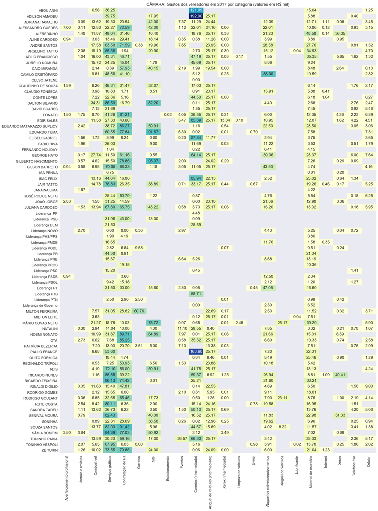

A análise na íntegra [está aqui](https://github.com/rodolfo-viana/ddj_stuff/blob/main/ipynb/2018-02-24-vereadores_correios.ipynb).

# Como funciona um site

A primeira coisa que precisamos compreender é como funciona a internet:

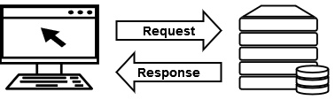

De forma simples:

1. o usuário, via browser, faz uma solicitação ao servidor do site (*request*);
2. o servidor responde à solicitação (*response*) entregando ao browser arquivos `.html`, `.css`, `.js` etc.;
3. o browser renderiza esses arquivos e transforma no que conhecemos como website.

Este ponto inicial é importante porque, quando falamos em raspagem de dados, **estamos falando de capturar informações que estão dentro de tags de HTML, atributos de CSS** etc.

De maneira ilustrada:

Quando abrimos um site qualquer temos na tela diversos elementos: textos de diversos tamanhos, estilos e cores; imagens que podem ser fotos ou ilustrações; gráficos de toda sorte; ícones de redes sociais.

[figure not shown]

[figure not shown]

[figure not shown]

Os elementos gráficos que vemos são **códigos renderizados**. São linhas de código (HTML, CSS, JavaScript etc.) que o navegador (Google Chrome, Firefox, Safari etc.) interpreta para apresentar ao usuário.

Por exemplo, o site do IDP é, na verdade, assim:

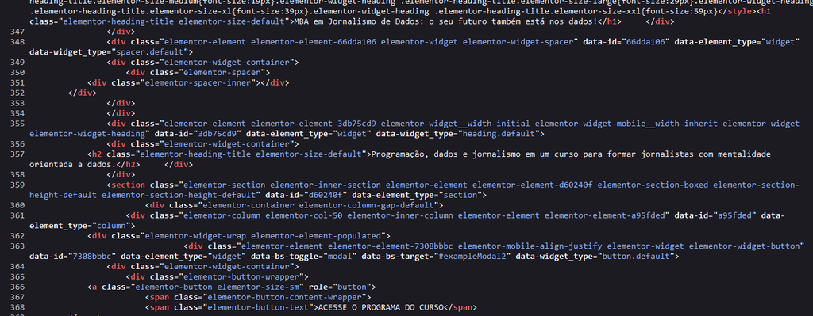

Este é só um trecho do código HTML do site, que o browser traduz em elementos gráficos.

Repare que, na linha 357, tem o texto *Programação, dados e jornalismo em um curso para formar jornalistas com mentalidade orientada a dados*. Ao redor deste texto tem uma tag (`<h2>`) e duas classes (`class="elementor-heading-title elementor-size-default"`). Essa tag e essas classes dizem para o navegador como o texto em questão deve ser interpretado.

Ou seja, se criarmos um script em Python para capturar a informação contida em `<h2 class="elementor-heading-title elementor-size-default">`, teremos como resposta *Programação, dados e jornalismo em um curso para formar jornalistas com mentalidade orientada a dados*.

Isso é raspagem de dados: **dizer ao script para visitar determinado site e trazer todos os dados "envelopados" por tags e atributos específicos**.

### HTML

Se as informações que estamos buscando estão em tags de HTML, precisamos compreender — ainda que superficialmente — como essas tags funcionam. **Não é necessário decorar HTML, mas entender sua lógica**.

Uma tag de HTML vem dentro de `<` e `>`, e indica o que é o elemento: título, parágrafo, imagem, lista etc. Muitas requerem indicação de fim da tag, com uso de `/`. Por exemplo:

```
<div>
    <h1>Lista de compras</h1>
    <p>Aqui estão os itens a serem comprados nesta semana:</p>
    <ul>
        <li>Arroz</li>
        <li>Feijão</li>
        <li>Óleo</li>
    </ul>
    <p>Em caso de dúvidas, acesse <a href="linkparaosite">este formulário</a></p>
</div>
```

No exemplo acima:

- `div` representa **container** para o conteúdo que segue
- `h1` significa **heading 1**, ou seja, cabeçalho, título. Traz o texto em letras grandes. Conforme o número aumenta (`h2`, `h3`, até `h6`), o tamanho da letra vai diminuindo
- `p` indica **parágrafo**
- `ul` representa que os elementos a seguir estão numa **lista não ordenada** (*unordered list*)
- `li` indica **item da lista**
- `a` indica **link**

Então o exemplo acima é renderizado pelo browser assim:

# Lista de compras

Aqui estão os itens a serem comprados nesta semana:

- Arroz
- Feijão
- Óleo

Em caso de dúvidas, acesse este formulário

### CSS

Como vimos, tags de HTML indicam o que é o elemento: parágrafo, título, lista etc. Mas ele não é o único componente. Há ainda **atributos de CSS**.

(Novamente, não é importante saber criar atributos de CSS, mas entender o que são e como funcionam.)

CSS significa *cascading style sheet*, ou folha de estilo em cascata. Seus atributos, portanto, indicam o estilo de um elemento. Em suma: **tag de HTML mostra *o que é* o elemento, e atributo de CSS mostra *como é* o elemento**.

Um exemplo:

```
<style>
    .verm{color:red;}
    .az{color:blue;}
</style>

<h1 class="verm">Título 1</h1>
<h1 class="az">Título 2</h1>
```

Repare que *Título 1* e *Título 2* são ambos `h1` — ou seja, são *headings*, títulos. Mas eles não são iguais: *Título 1* tem a classe `verm`, enquanto *Título 2* tem a classe `az`. Essas classes estão definidas na tag `style`: `verm` deixa o elemento vermelho; `az`, azul.

Com isso, apesar de ambos serem `h1`, são interpretados pelo browser assim:

# Título 1

# Título 2

É possível ainda usar mais de um atributo para o mesmo elemento. Vejamos outro exemplo a partir do mesmo código:

```
<style>
    .verm{color:red;}
    .az{color:blue;}
    .mono{font-family:monospace;}
    .serif{font-family:serif;}
</style>

<h1 class="verm mono">Título 1</h1>
<h1 class="az serif">Título 2</h1>
```

Aqui, não apenas mudamos as cores de cada `h1`, como a família da fonte. Agora os elementos são interpretados assim:

# Título 1

# Título 2

# Ferramentas

Conforme dito anteriormente, há diversas formas de se fazer *web scraping*, tanto com uso de linguagens como Python, R e JavaScript, como sem qualquer tipo de programação, com aplicações como webscraper.io. Neste curso, usaremos Python e algumas bibliotecas externas:

- [Requests](https://requests.readthedocs.io/en/latest/), para capturar o conteúdo de sites.
- [BeautifulSoup](https://www.crummy.com/software/BeautifulSoup/bs4/doc/), para interpretar o conteúdo capturado por Requests.

Vamos discorrer sobre essas bibliotecas nas próximas aulas. Por ora, é necessário instalá-las, apenas. No Prompt de Comando (Windows) ou Terminal (MacOS/Linux), digite:

`python -m pip install requests beautifulsoup4`

ou:

`python3 -m pip install requests beautifulsoup4`

As bibliotecas serão instaladas e poderão ser usadas nos scripts de *web scraping*.

**Mais sobre os tópicos da aula**

- Vídeos
  - [Curso de HTML e CSS para iniciantes](https://www.youtube.com/playlist?list=PLwgL9IEA0PxUjbhob9UMdpVq12sGrjgU6), em Chief of Design
- Leituras
  - [Estruturando a web com HTML](https://developer.mozilla.org/pt-BR/docs/Learn/HTML), em MDN Web Docs
  - [Aprenda a estilizar HTML utilizando CSS](https://developer.mozilla.org/pt-BR/docs/Learn/CSS), em MDN Web Docs
  - [Documentação de Requests](https://requests.readthedocs.io/en/latest/) [inglês]
  - [Documentação de Beautiful Soup](https://www.crummy.com/software/BeautifulSoup/bs4/doc/index.html) [inglês]

**Atividade 1**

Imaginemos que o Brasil tenha um ministério exclusivo para riachos. É o Ministério dos Riachos Brasileiros. Como deve ser, o ministério disponibiliza em seu site a agenda do ministro, com os compromissos, locais, datas e horários. [Aqui está a agenda](http://rodolfoviana.com.br/idp/webscraping/agenda.html).

Olhando o código-fonte do site, partindo de `body`, indique o caminho (tags de HTML e atributos de CSS, esse último indicado por `.`) para chegar aos conteúdos indicados abaixo.

- "Reunião com pescadores"
- "Sede da ATRB"
- "18:30"

Exemplo: para chegar em "Dados abertos" no rodapé da página:

`body > footer > div.container > div.row > div.col-lg-6 mb-6 [2] > ul > li [3]`

**Atividade 2**

No código-fonte, apesar dos textos dos compromissos serem diferentes, reparem que muitas tags e atributos se repetem. Se eu quiser raspar os compromissos, quais tags e atributos eu devo pegar?